# Jobs Day

The Penny Hoarder Data Desk

This is the latest report on job growth by industry for the month of December — the last one of 2018. The unemployment rate for this month is **3.9%**. That’s a **0.2** percentage point change from the previous month, and a **-0.2** percentage point change from the same month last year.

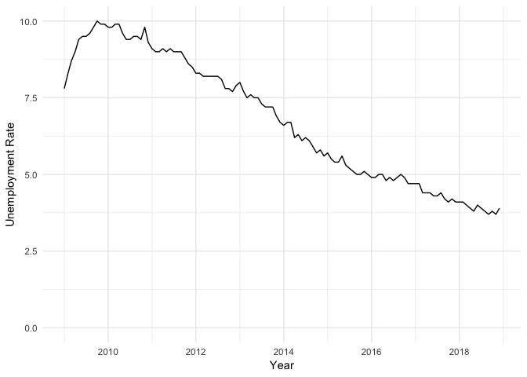

But, when we look at alternative measures of unemployment, you can see this month’s U-6 rate is at **7.6%**. That’s a **0** percentage point change from the previous month, and a **-0.5** percentage point change from the same month last year.

(U-6 measures the number of folks who are on contract and expecting it to end, those who are discouraged and those who are working part-time because they can’t find a full-time job.)

The monthly and annual change in employment is reflected in percent change.

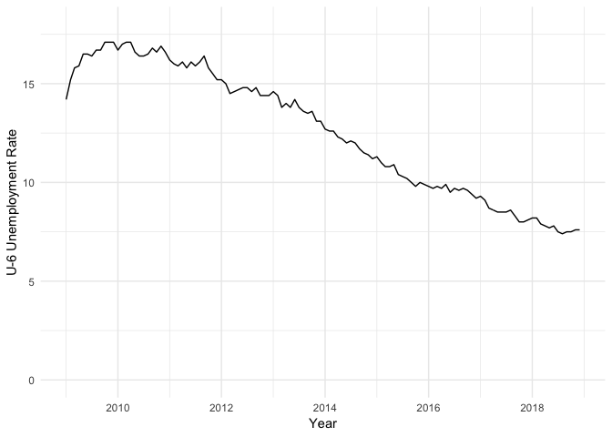

Now, let’s take a look at the employment change by industry. The monthly and annual change is in thousands.

|  | Industry | Current Month | Monthly Change | Annual Change | Monthly % Change | Annual % Change |
| --- | --- | --- | --- | --- | --- | --- |
| 1 | Total nonfarm | 150263 | 312 | 2638 | 0.21 | 1.79 |
| 2 | Total private | 127858 | 301 | 2564 | 0.24 | 2.05 |
| 3 | Goods-producing | 20952 | 74 | 624 | 0.35 | 3.07 |
| 4 | Mining and logging | 758 | 4 | 60 | 0.53 | 8.6 |
| 5 | Logging | 47.1 | 0.6 | -2.6 | 1.29 | -5.23 |
| 6 | Mining | 710.7 | 3.7 | 62.4 | 0.52 | 9.63 |
| 7 | Oil and gas extraction | 154.7 | 0.3 | 10.2 | 0.19 | 7.06 |
| 8 | Mining, except oil and gas | 192.1 | 0.9 | 6.3 | 0.47 | 3.39 |
| 9 | Coal mining | 53.9 | 0.6 | 2.1 | 1.13 | 4.05 |
| 10 | Metal ore mining | 38.4 | -0.1 | 0 | -0.26 | 0 |

[output cut: 165 more lines]

|  | Industry | Current Month | Monthly Change | Annual Change | Monthly % Change | Annual % Change |
| --- | --- | --- | --- | --- | --- | --- |
| 1 | Total private | 27.48 | 0.11 | 0.84 | 0.4 | 3.15 |
| 2 | Goods-producing | 28.61 | 0.11 | 0.77 | 0.39 | 2.77 |
| 3 | Mining and logging | 33.07 | 0 | 0.83 | 0 | 2.57 |
| 4 | Construction | 30.44 | 0.15 | 1.13 | 0.5 | 3.86 |
| 5 | Manufacturing | 27.3 | 0.07 | 0.53 | 0.26 | 1.98 |
| 6 | Durable goods | 28.76 | 0.05 | 0.71 | 0.17 | 2.53 |
| 7 | Nondurable goods | 24.79 | 0.09 | 0.21 | 0.36 | 0.85 |
| 8 | Private service-providing | 27.21 | 0.1 | 0.85 | 0.37 | 3.22 |
| 9 | Trade, transportation, and utilities | 23.8 | 0.16 | 0.76 | 0.68 | 3.3 |
| 10 | Wholesale trade | 31.04 | 0.17 | 0.74 | 0.55 | 2.44 |

[output cut: 9 more lines]